# Low Birth Rates Analysis_US

# Introduction

What is the relationship between low birth rates and smoking and alcohol consumption in the U.S.? It is important to note that is aggregate data and not individual cases.

```r
library(nlme)
library(dplyr)
library(magrittr)
library(tidyr)
library(haven)
library(lmerTest)
library(ggplot2)
library(texreg)
```

```r
library(radiant.data)
library(readr)
  lbr1 <- read_csv("/Users/Cruz/Desktop/lbr.csv", col_names = TRUE)
   head(lbr1)
```

| Geo_FIPS | Geo_NAME | Geo_QNAME | Geo_STATE | Geo_COUNTY | SE_T003_001 | SE_NV002_001 | SE_T011_001 | SE_T011_002 |
| --- | --- | --- | --- | --- | --- | --- | --- | --- |
| 01001 | Autauga County | Autauga County, Alabama | 01 | 001 | 8.786701 | 407 | 18.7 | 15.1 |
| 04001 | Apache County | Apache County, Arizona | 04 | 001 | 6.950540 | 586 | 25.6 | 14.6 |
| 05001 | Arkansas County | Arkansas County, Arkansas | 05 | 001 | 11.423748 | 203 | 22.4 | 13.9 |
| 06001 | Alameda County | Alameda County, California | 06 | 001 | 7.243144 | 10132 | 10.6 | 16.3 |
| 08001 | Adams County | Adams County, Colorado | 08 | 001 | 8.722471 | 4214 | 18.1 | 18.5 |
| 09001 | Fairfield County | Fairfield County, Connecticut | 09 | 001 | 7.630721 | 5690 | 14.2 | 18.3 |

# Preparing Data for Analysis

```r
lbr1 <- rename(lbr1, state = Geo_STATE, county = Geo_COUNTY, lowbirth = SE_NV002_001,smokers = SE_T011_001,alcohol = SE_T011_002)
```

# Data Cleaning

Originally the data contained 3141 observations. After running na.omit the leftover cases were 3041 observations.

```r
lbr1<-na.omit(lbr1)
head(lbr1)
```

| Geo_FIPS | Geo_NAME | Geo_QNAME | state | county | SE_T003_001 | lowbirth | smokers | alcohol |
| --- | --- | --- | --- | --- | --- | --- | --- | --- |
| 01001 | Autauga County | Autauga County, Alabama | 01 | 001 | 8.786701 | 407 | 18.7 | 15.1 |
| 04001 | Apache County | Apache County, Arizona | 04 | 001 | 6.950540 | 586 | 25.6 | 14.6 |
| 05001 | Arkansas County | Arkansas County, Arkansas | 05 | 001 | 11.423748 | 203 | 22.4 | 13.9 |
| 06001 | Alameda County | Alameda County, California | 06 | 001 | 7.243144 | 10132 | 10.6 | 16.3 |
| 08001 | Adams County | Adams County, Colorado | 08 | 001 | 8.722471 | 4214 | 18.1 | 18.5 |
| 09001 | Fairfield County | Fairfield County, Connecticut | 09 | 001 | 7.630721 | 5690 | 14.2 | 18.3 |

# Preliminary Investigation of “Low Birth Rate In The U.S”

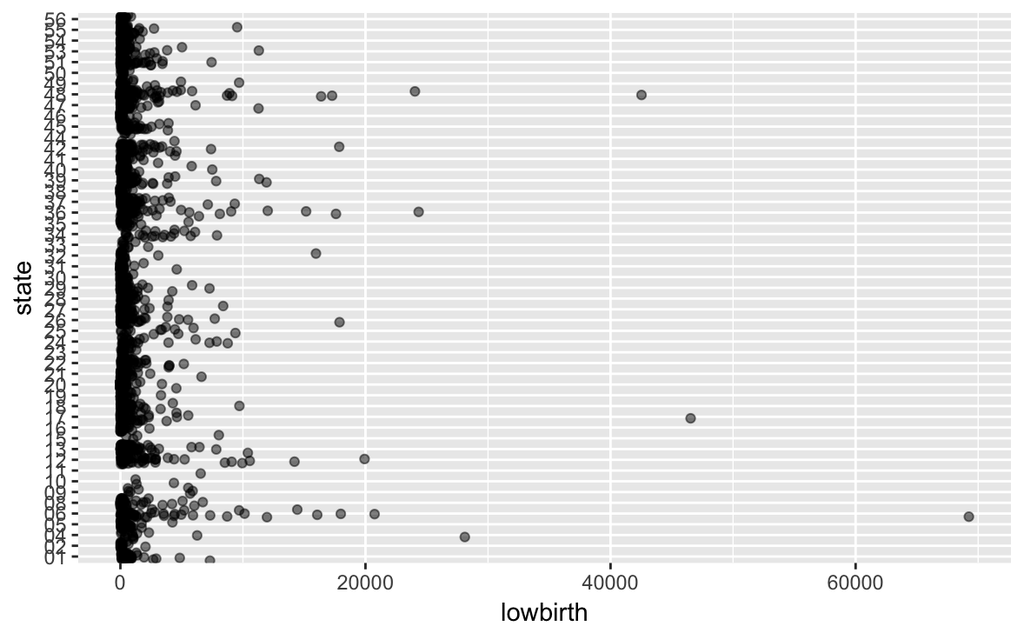

```r
ggplot(lbr1, aes(x = lowbirth, y = state)) + geom_jitter(alpha = 0.5)
```

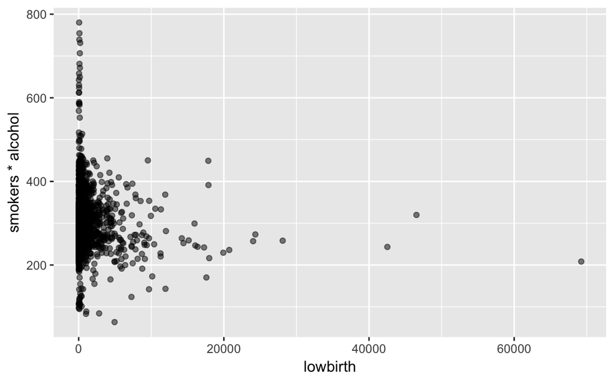

```r
ggplot(lbr1, aes(x = lowbirth, y = smokers*alcohol)) + geom_jitter(alpha = 0.5)
```

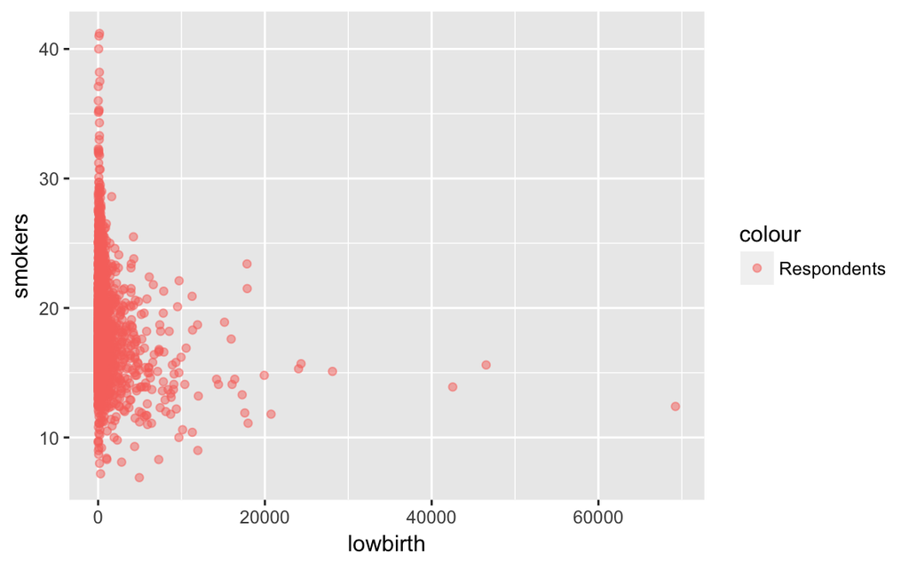

```r
ggplot(lbr1, aes(x = lowbirth, y = smokers, color = "Respondents")) + geom_jitter(alpha = 0.5)
```

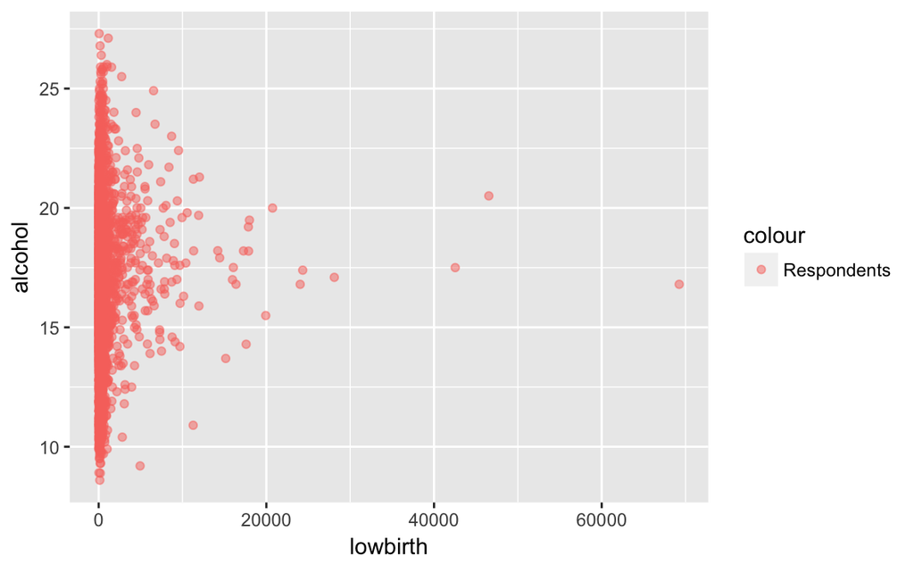

```r
ggplot(lbr1, aes(x = lowbirth, y = alcohol, color = "Respondents")) + geom_jitter(alpha = 0.5)
```

# Fixing the preliminary by state to display actual state and not number.

We see that Texas and California have the highest low birth rates in the United States.

```r
library(radiant.data)
library(readr)

library(stringr)
X<-data.frame(str_locate(lbr1$Geo_QNAME,"County,"))
X2<-X%>%select(end)
lbr1$loc <- X2$end
lbr1<-lbr1%>%
  mutate(statename = substr(Geo_QNAME, loc+1,length(Geo_QNAME)))
lbr1
```

| Geo_FIPS | Geo_NAME | Geo_QNAME | state | county | SE_T003_001 | lowbirth | smokers | alcohol | loc | statename |
| --- | --- | --- | --- | --- | --- | --- | --- | --- | --- | --- |
| 01001 | Autauga County | Autauga County, Alabama | 01 | 001 | 8.786701 | 407 | 18.7 | 15.1 | 15 | Alabama |
| 04001 | Apache County | Apache County, Arizona | 04 | 001 | 6.950540 | 586 | 25.6 | 14.6 | 14 | Arizona |
| 05001 | Arkansas County | Arkansas County, Arkansas | 05 | 001 | 11.423748 | 203 | 22.4 | 13.9 | 16 | Arkansas |
| 06001 | Alameda County | Alameda County, California | 06 | 001 | 7.243144 | 10132 | 10.6 | 16.3 | 15 | California |
| 08001 | Adams County | Adams County, Colorado | 08 | 001 | 8.722471 | 4214 | 18.1 | 18.5 | 13 | Colorado |
| 09001 | Fairfield County | Fairfield County, Connecticut | 09 | 001 | 7.630721 | 5690 | 14.2 | 18.3 | 17 | Connecticut |
| 10001 | Kent County | Kent County, Delaware | 10 | 001 | 8.476975 | 1318 | 18.2 | 15.3 | 12 | Delaware |
| 11001 | District of Columbia County | District of Columbia County, District of Columbia | 11 | 001 | 10.214266 | 6550 | 15.8 | 24.9 | 28 | District of Columbia |
| 12001 | Alachua County | Alachua County, Florida | 12 | 001 | 8.705522 | 1764 | 18.2 | 20.3 | 15 | Florida |
| 13001 | Appling County | Appling County, Georgia | 13 | 001 | 10.652174 | 196 | 17.9 | 14.2 | 15 | Georgia |

[output cut: 990 more lines]

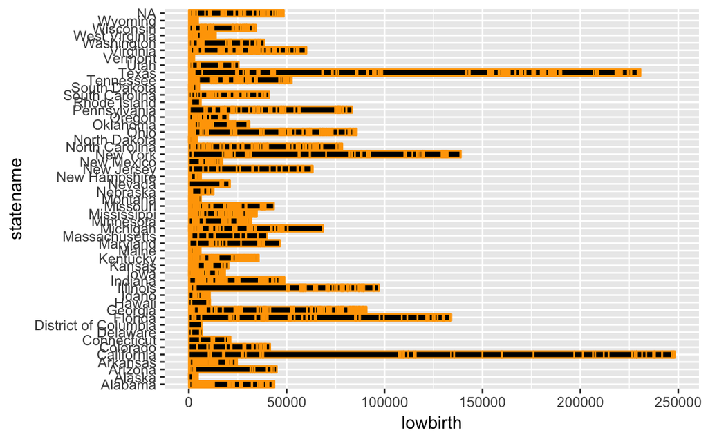

```r
ggplot(data=lbr1, aes(x=statename, y=lowbirth))+
  geom_col(color ="orange", fill = "black")+coord_flip()
```

# MULTI-LEVEL ANALYSIS X RANDOM EFFECTS

In understanding low birth rates in the U.S I am using state as higher level observation.